#### Mean Customer Lifetime Value for each Sales Channel

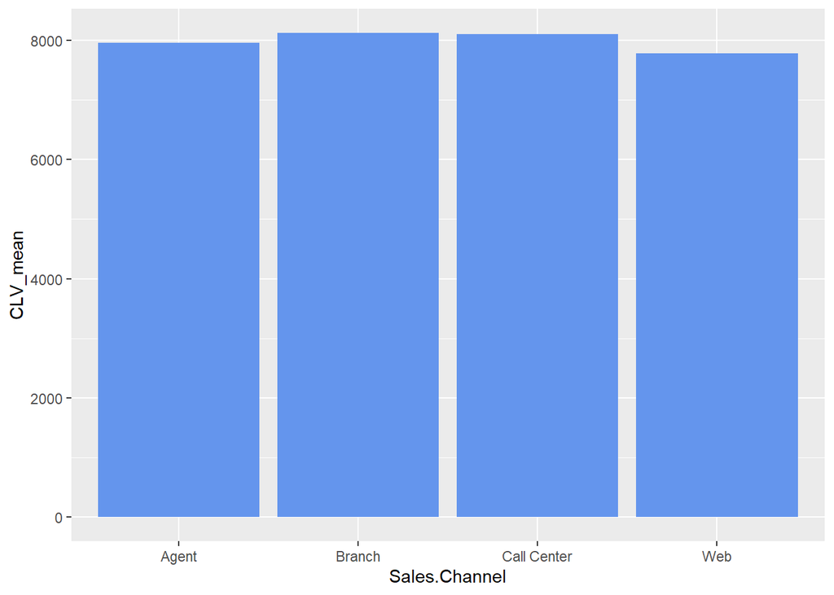

```r
plotdata <- data %>%
  group_by(Sales.Channel) %>%
  summarize(CLV_mean = mean(CLV))

# plot mean Customer Lifetime Value
ggplot(plotdata,
       aes(x =Sales.Channel,
           y = CLV_mean)) +
   geom_text(aes(label = CLV_mean),
            size = 3,
            position = position_stack(vjust = 0.5)) +
  geom_bar(stat = "identity",fill = "cornflowerblue")
```

The highest Mean Customer Lifetime Value is for Branch sales Channel this is because customers directly approaching the branch are done direct canvasing and they get the information about the benefits without any information leakage.

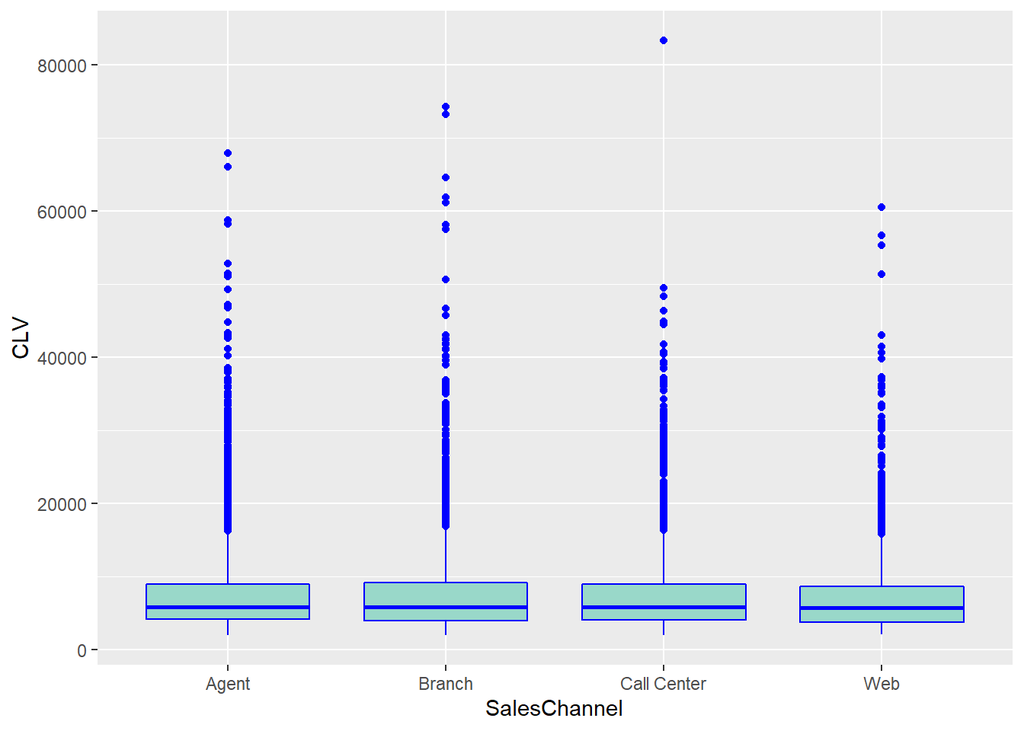

```r
ggplot(df, aes(x = SalesChannel, y = CLV)) +
  geom_boxplot(col = "blue",outlier.colour = "blue",fill ="#99D8C9")
```

One of the CLV for Call Center is significantly high and branch has succeeded in obtaining some number of customers with high CLV.

#### Count of customers from each Vehicle Class

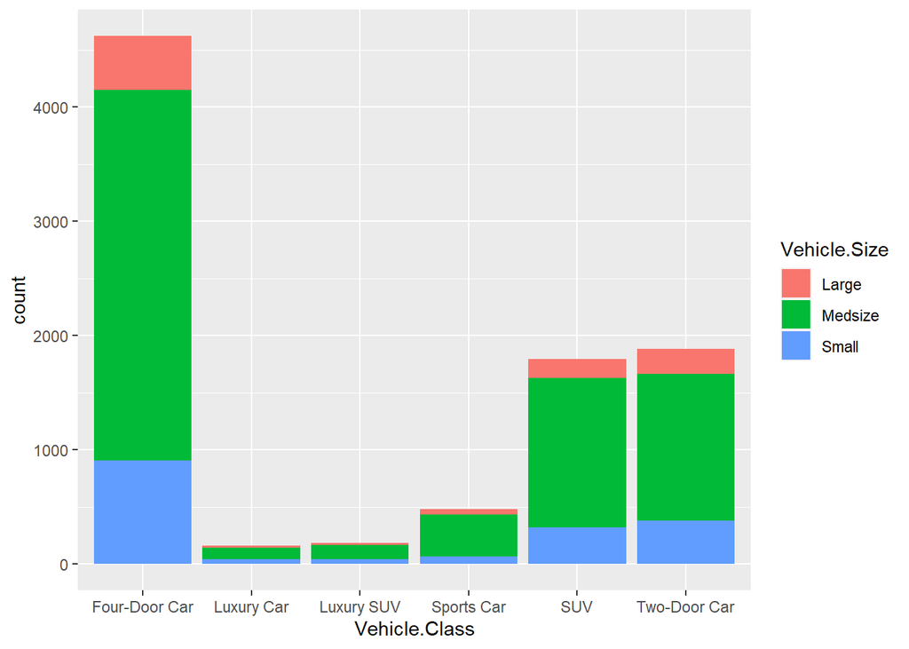

```r
ggplot(data,
       aes(x = Vehicle.Class,
           fill = Vehicle.Size)) +
  geom_bar(position = "stack")
```

The normal Four-Door Vehicle has the maximum count when compared with other vehicle classes and luxury car have comparitively a very low count.

#### Mean Customer Lifetime Value for each Vehicle Class

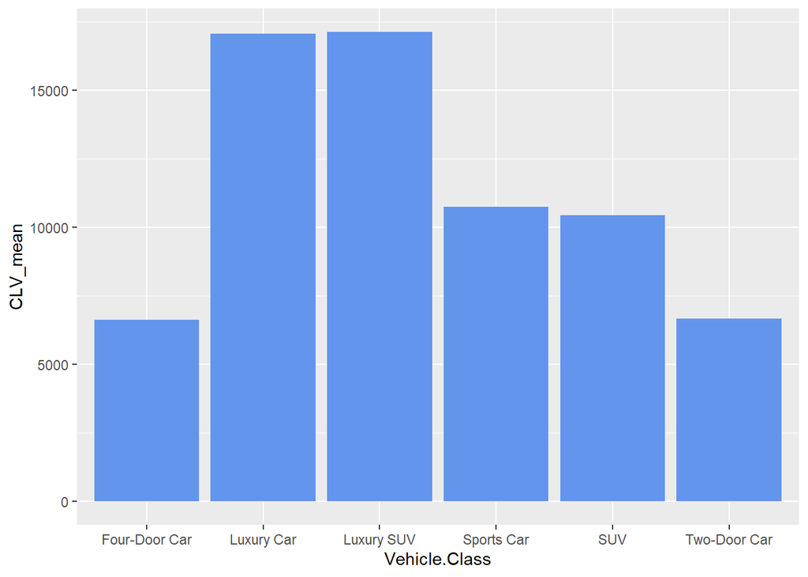

```r
plotdata <- data %>%
  group_by(Vehicle.Class) %>%
  summarize(CLV_mean = mean(CLV))

# plot mean Customer Lifetime Value
ggplot(plotdata,
       aes(x =Vehicle.Class,
           y = CLV_mean)) +
   geom_text(aes(label = CLV_mean),
            size = 1,
            position = position_stack(vjust = 0.2)) +
  geom_bar(stat = "identity",fill = "cornflowerblue")
```

Since luxury cars are very costly they have a very high Mean Customer Lifetime Value.

#### Count of customers from each Vehicle Size

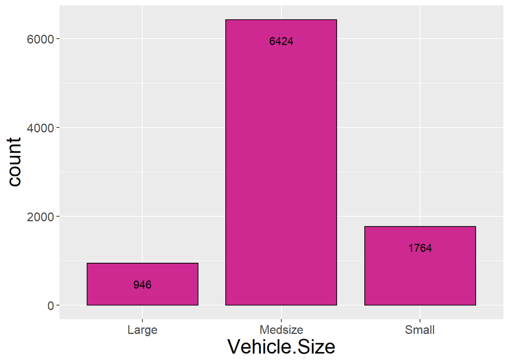

```r
ggplot(data,
       aes(x = Vehicle.Size)) +
  geom_bar(position = "identity",fill = "maroon3",col="black",width=0.8)+
    geom_text(stat="Count",aes(label = after_stat(count)),vjust=3)+
    theme(
        text=element_text(size=15),
        axis.title.x = element_text(color="black", size=20),
        axis.title.y = element_text(color="black", size=20)
    )
```

People mostly prefer medium sized vehicles so the count for that category is significantly high.

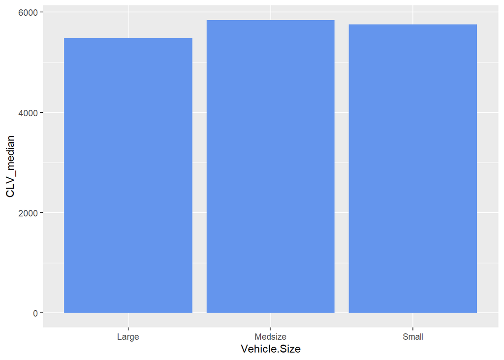

```r
plotdata <- data %>%
  group_by(Vehicle.Size) %>%
  summarize(CLV_median = median(CLV))

# plot mean Customer Lifetime Value
ggplot(plotdata,
       aes(x =Vehicle.Size,
           y = CLV_median)) +
   geom_text(aes(label = CLV_median),
            size = 3,
            position = position_stack(vjust = 0.5)) +
  geom_bar(stat = "identity",fill = "cornflowerblue")
```

The median Customer Lifetime Value is higher for medium sized vehicles.

#### Count of customers from each Response

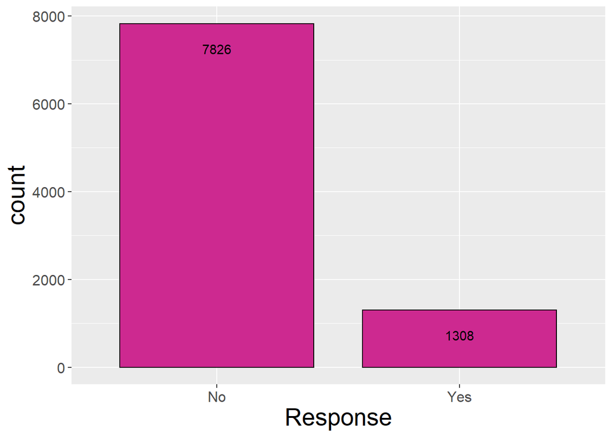

```r
ggplot(data,
       aes(x = Response)) +
  geom_bar(position = "identity",fill = "maroon3",col="black",width=0.8)+
    geom_text(stat="Count",aes(label = after_stat(count)),vjust=3)+
    theme(
        text=element_text(size=15),
        axis.title.x = element_text(color="black", size=20),
        axis.title.y = element_text(color="black", size=20)
    )
```

The negative response customers is quiet high than positive response customers

#### Mean Customer Lifetime Value for each Response

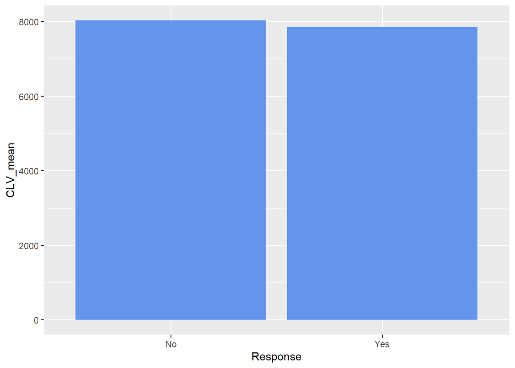

```r
plotdata <- data %>%
  group_by(Response) %>%
  summarize(CLV_mean = mean(CLV))

# plot mean Customer Lifetime Value
ggplot(plotdata,
       aes(x =Response,
           y = CLV_mean)) +
   geom_text(aes(label = CLV_mean),
            size = 3,
            position = position_stack(vjust = 0.5)) +
  geom_bar(stat = "identity",fill = "cornflowerblue")
```

Eventhough there is a significant difference between the count of each response type the mean Customer Lifetime Value does not have much variation from eachother.

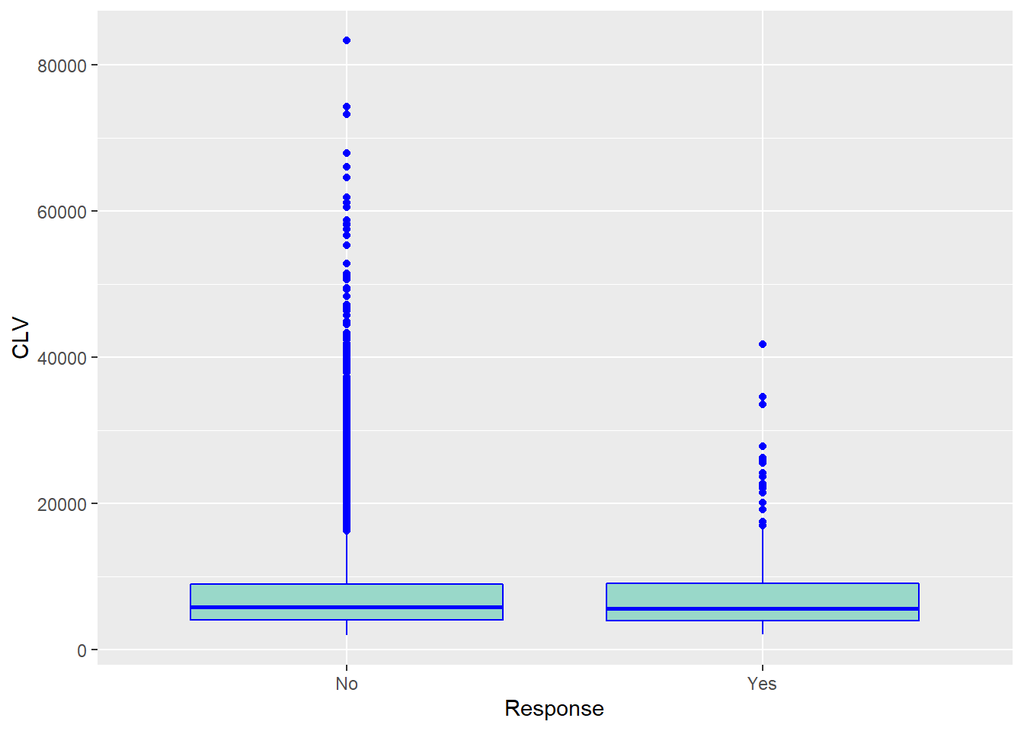

```r
ggplot(df, aes(x = Response, y = CLV)) +
  geom_boxplot(col = "blue",outlier.colour = "blue",fill ="#99D8C9")
```

Customers who showed negative response to the policy plan has a significantly amount of outliers in terms of the CLV value and most of them are quiet high high CLV values.